# Two Decades of Household Purchasing: A SQL Analysis

- Show All Code
- Hide All Code
- View Source

Author

Zoe Finiasz

How does an occasional customer become a habitual one? This case study uses SQL (DuckDB) to trace two decades of one household’s Amazon order history, 2004–2024: 2,715 items across 1,505 orders.

## Key findings

- **2009–10 marked a sharp increase in purchasing.** Until 2008 the household placed 2–7 orders a year in large batches. By 2010 it was ordering about weekly, 1–2 items at a time, and from 2014 on it shopped every 2–4 days.
- **This jump aligned with a subscription to Amazon Prime.** No order shipped free through 2006; about three-quarters did by 2009–11 and nearly all from 2012.
- **Purchases shifted from books to all kinds of items.** Books, movies and music were three-quarters of purchases in 2004–08 and 3% by 2020–24; groceries tripled from 2020 on, with the pandemic.
- **The habit spread from parents to their children.** The parents made nearly every purchase until 2014; as the children left for college, they began making their own purchases.
- **Prime Day replaced the holidays as the peak.** Before 2015, November and December held 27% of orders; since then, July has been the busiest month.

## 1. Purchasing habits

I rolled line items up to one row per order, then tracked per year how many orders were placed, in how many months, how large they were, and how many days passed between shopping days.

**Show SQL**

```sql
-- One row per order; used throughout the analysis
CREATE OR REPLACE VIEW order_level AS
SELECT order_num,
       MIN(purchase_date)       AS order_date,
       year(MIN(purchase_date)) AS year,
       COUNT(*)                 AS items,
       SUM(total_item)          AS order_spend,
       SUM(shipping)            AS ship_paid
FROM orders
WHERE order_num IS NOT NULL
GROUP BY order_num;
```

**Show SQL**

```sql
CREATE OR REPLACE VIEW habit_by_year AS
WITH shop_days AS (            -- several orders on one day = one shopping day
  SELECT DISTINCT order_date FROM order_level
),
gaps AS (                      -- days since the previous shopping day
  SELECT order_date,
         date_diff('day', LAG(order_date) OVER (ORDER BY order_date),
                   order_date) AS days_since_prev
  FROM shop_days
),
yearly_orders AS (
  SELECT year,
         COUNT(*)                          AS orders,
         COUNT(DISTINCT month(order_date)) AS active_months,
         AVG(items)                        AS items_per_order
  FROM order_level
  GROUP BY year
),
yearly_gaps AS (
  SELECT year(order_date) AS year,
         MEDIAN(days_since_prev) AS median_days_between
  FROM gaps
  GROUP BY 1
)
SELECT year, o.orders, o.active_months, o.items_per_order, g.median_days_between
FROM yearly_orders o
JOIN yearly_gaps   g USING (year);
```

**Show SQL**

```sql
-- Long format (one row per year x measure) for small multiples
SELECT *
FROM (
  SELECT year,
         CAST(orders              AS DOUBLE) AS orders,
         CAST(active_months       AS DOUBLE) AS active_months,
         CAST(items_per_order     AS DOUBLE) AS items_per_order,
         CAST(median_days_between AS DOUBLE) AS median_days_between
  FROM habit_by_year
)
UNPIVOT (
  value FOR metric IN (orders, active_months, items_per_order, median_days_between)
);
```

**Show R**

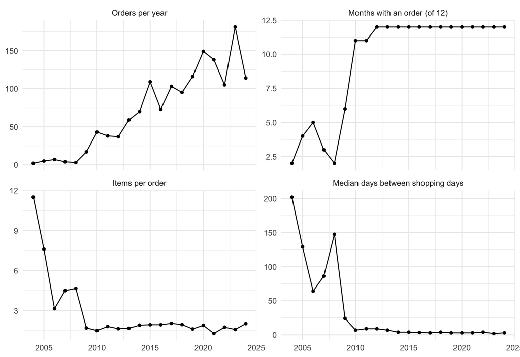

```r
habit_long$metric <- factor(
  habit_long$metric,
  levels = c("orders", "active_months", "items_per_order", "median_days_between"),
  labels = c("Orders per year", "Months with an order (of 12)",
             "Items per order", "Median days between shopping days")
)

ggplot(habit_long, aes(year, value)) +
  geom_line(na.rm = TRUE) +
  geom_point(size = 1.2, na.rm = TRUE) +
  facet_wrap(~ metric, scales = "free_y", ncol = 2) +
  labs(x = NULL, y = NULL) +
  theme_minimal()
```

**Show SQL**

```sql
-- Before / during / after summary, with the parents alone as a robustness check
WITH periods AS (
  SELECT *,
         CASE WHEN year <= 2008 THEN '2004–08'
              WHEN year <= 2011 THEN '2009–11'
              ELSE '2012–24' END AS period
  FROM order_level
),
parent_orders AS (             -- orders with at least one item for the parents
  SELECT DISTINCT order_num FROM orders WHERE shopper = 'Parents'
),
gaps AS (
  SELECT order_date,
         date_diff('day', LAG(order_date) OVER (ORDER BY order_date),
                   order_date) AS days_since_prev
  FROM (SELECT DISTINCT order_date FROM order_level)
),
period_gaps AS (
  SELECT CASE WHEN year(order_date) <= 2008 THEN '2004–08'
              WHEN year(order_date) <= 2011 THEN '2009–11'
              ELSE '2012–24' END AS period,
         MEDIAN(days_since_prev) AS median_days_between
  FROM gaps
  GROUP BY 1
)
SELECT p.period                                   AS "Time period",
       ROUND(COUNT(*) / COUNT(DISTINCT p.year), 1) AS "Orders per year",
       ROUND(COUNT(*) FILTER (WHERE p.order_num IN (SELECT order_num FROM parent_orders))
             / COUNT(DISTINCT p.year), 1)         AS "Parents' orders per year",
       ROUND(AVG(p.items), 1)                     AS "Items per order",
       ANY_VALUE(g.median_days_between)           AS "Median days between purchases"
FROM periods p
JOIN period_gaps g USING (period)
GROUP BY p.period
ORDER BY p.period;
```

| Time period | Orders per year | Parents’ orders per year | Items per order | Median days between purchases |
| --- | --- | --- | --- | --- |
| 2004–08 | 4.2 | 4.2 | 5.5 | 87.0 |
| 2009–11 | 32.7 | 32.3 | 1.7 | 8.5 |
| 2012–24 | 103.8 | 77.5 | 1.8 | 3.0 |

**Takeaway:** Buying shifted from occasional stock-ups to routine top-ups in 2009–2010, and the pattern then held for more than a decade. The two children started using the account around then, but bought very little before 2015; the parents’ orders alone went from about 4 a year to 32, so the change reflects behavior, not headcount.

## 2. Amazon Prime

Shipping *cost* dropped with the purchase of a Prime membership. Once this happened, order frequency increased.

**Show SQL**

```sql
SELECT year,
       100.0 * COUNT(*) FILTER (WHERE ship_paid = 0) / COUNT(*) AS pct_free_shipping
FROM order_level
GROUP BY year
ORDER BY year;
```

**Show R**

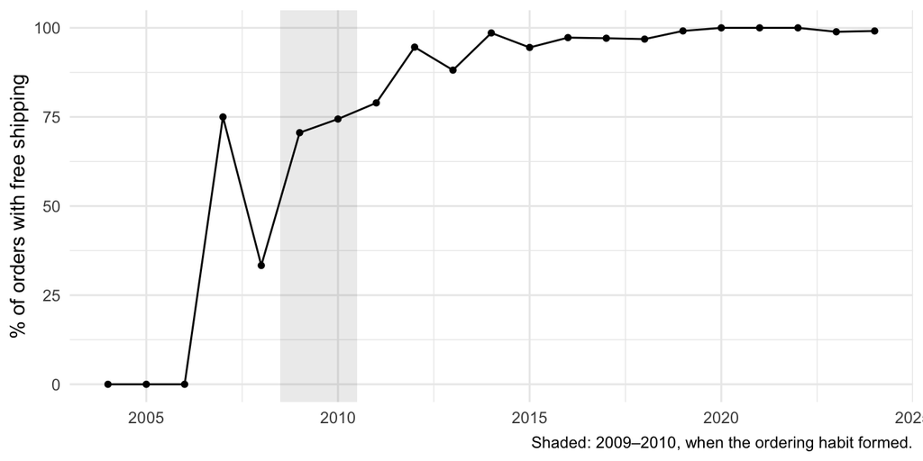

```r
ggplot(ship_by_year, aes(year, pct_free_shipping)) +
  annotate("rect", xmin = 2008.5, xmax = 2010.5, ymin = -Inf, ymax = Inf,
           alpha = 0.12) +
  geom_line(na.rm = TRUE) +
  geom_point(size = 1.2, na.rm = TRUE) +
  labs(x = NULL, y = "% of orders with free shipping",
       caption = "Shaded: 2009–2010, when the ordering habit formed.") +
  theme_minimal()
```

**Show SQL**

```sql
-- Membership or minimum-order rule? Compare free vs. paid orders, 2007–2014
SELECT CASE WHEN ship_paid = 0 THEN 'Free' ELSE 'Paid' END AS "Shipping",
       COUNT(*)                                        AS "Orders",
       ROUND(AVG(items), 1)                            AS "Items per order",
       printf('$%.2f', MEDIAN(order_spend))            AS "Median order spend",
       COUNT(*) FILTER (WHERE order_spend < 25)        AS "Orders under $25"
FROM order_level
WHERE year BETWEEN 2007 AND 2014
GROUP BY 1
ORDER BY 1;
```

| Shipping | Orders | Items per order | Median order spend | Orders under $25 |
| --- | --- | --- | --- | --- |
| Free | 234 | 1.9 | $36.34 | 83 |
| Paid | 37 | 1.2 | $22.01 | 19 |

**Takeaway:** Free shipping was not available through 2006, but was used on about three-quarters of all orders (2009–11) to nearly all orders (2012 on). Free orders were somewhat larger than paid ones, as a minimum-order rule would predict, but over a third cost under $25, which points to a free-shipping membership too.

## 3. What was purchased

Each item was assigned one broad category during preprocessing (see the appendix). Here I compare the category mix across four periods.

**Show SQL**

```sql
WITH counts AS (
  SELECT CASE WHEN purchase_year <= 2008 THEN '2004–08'
              WHEN purchase_year <= 2014 THEN '2009–14'
              WHEN purchase_year <= 2019 THEN '2015–19'
              ELSE '2020–24' END AS period,
         category,
         COUNT(*) AS items
  FROM orders
  GROUP BY 1, 2
),
grid AS (   -- every period x category, so empty cells exist as 0
  SELECT p.period, c.category
  FROM (SELECT DISTINCT period FROM counts) p
  CROSS JOIN (SELECT DISTINCT category FROM counts) c
)
SELECT g.period, g.category,
       coalesce(n.items, 0) AS items,
       100.0 * coalesce(n.items, 0)
             / SUM(coalesce(n.items, 0)) OVER (PARTITION BY g.period) AS pct
FROM grid g
LEFT JOIN counts n USING (period, category);
```

Each cell shows the share of that period’s items. Outlined cells mark turning points; hover over them for context.

**Show R**

```r
# Order categories by total items, largest at the top
totals <- aggregate(items ~ category, cat_period, sum)
lvls <- totals$category[order(totals$items)]
cat_period$category <- factor(cat_period$category, levels = lvls)

# The cells the story turns on: outlined, and the only ones with a tooltip
highlights <- data.frame(
  category = factor(c("Books", "Health & personal care", "Grocery & food"),
                    levels = lvls),
  period   = c("2004–08", "2015–19", "2020–24"),
  note     = c(
    "Books were 62% of purchases. Fulfillment by Amazon (2006) then let outside sellers use Amazon's warehouses and shipping, so far more kinds of goods shipped fast and free; by 2009–14, books were down to 22%.",
    "Mostly fitness supplements and protein products, as one household member took up strength training.",
    "Grocery delivery took off with the COVID-19 pandemic: 5% of items before 2020, 15% after."
  )
)
highlights$tooltip <- paste0(
  "<b>", highlights$category, ", ", highlights$period, "</b><br>",
  sapply(highlights$note, function(x) paste(strwrap(x, 48), collapse = "<br>"))
)

p <- ggplot(cat_period, aes(period, category)) +
  geom_tile(aes(fill = pct), color = "white", linewidth = 1) +
  geom_text(aes(label = ifelse(items == 0, "", sprintf("%.0f%%", pct)),
                color = pct > 20), size = 3.2) +
  geom_tile(data = highlights, fill = NA, color = "#e07b00", linewidth = 1.3) +
  # invisible points at the highlighted cells carry the tooltips
  geom_point(data = highlights, aes(text = tooltip), size = 12, alpha = 0) +
  scale_fill_gradient(low = "#f2f2f2", high = "#2b4c7e", guide = "none") +
  scale_color_manual(values = c(`FALSE` = "black", `TRUE` = "white"), guide = "none") +
  labs(x = NULL, y = NULL) +
  theme_minimal() +
  theme(panel.grid = element_blank())

gp <- ggplotly(p, tooltip = "text")
# hover only on the highlight points; every other layer is skipped
gp$x$data <- lapply(gp$x$data, function(tr) {
  tr$hoverinfo <- if (identical(tr$mode, "markers")) "text" else "skip"
  tr
})
gp |>
  layout(hoverlabel = list(align = "left", bgcolor = "white"),
         showlegend = FALSE) |>
  config(displayModeBar = FALSE)
```

[interactive chart not shown]

**Takeaway:** Amazon went from the household’s media store to its everything store. In 2004–08, three of every four items were books, movies or music. By 2020–24, media purchases fell to 3%. Instead purchases were spread across clothing (23%), health and personal care (18%), home (15%) and groceries (15%).

The shifts line up with outside events: the move beyond media followed Amazon’s opening to outside sellers through Fulfillment by Amazon (2006); health and personal care peaked in 2015–19, when one household member took up strength training; and groceries tripled from 2020, with the pandemic.

## 4. Parents vs. children

The account was shared by two parents, and two children. To keep the focus on shopping behavior rather than on individuals, I compare the two generations (parents and children) and look at how each shops.

**Show SQL**

```sql
-- Each shopper's profile
SELECT shopper                                                AS "Shopper",
       MIN(purchase_year)                                     AS "First year",
       COUNT(DISTINCT order_num)                              AS "Orders",
       COUNT(*)                                               AS "Items",
       ROUND(COUNT(*) * 1.0 / COUNT(DISTINCT order_num), 1)   AS "Items per order",
       printf('$%.2f', MEDIAN(total_item))                    AS "Median item cost"
FROM orders
GROUP BY shopper
ORDER BY COUNT(*) DESC;
```

| Shopper | First year | Orders | Items | Items per order | Median item cost |
| --- | --- | --- | --- | --- | --- |
| Parents | 2004 | 1125 | 2094 | 1.9 | $19.13 |
| Children | 2010 | 343 | 583 | 1.7 | $14.89 |

**Show SQL**

```sql
-- Each shopper's share of the household's items, by period
SELECT period, shopper, items,
       100.0 * items / SUM(items) OVER (PARTITION BY period) AS pct
FROM (
  SELECT CASE WHEN purchase_year <= 2008 THEN '2004–08'
              WHEN purchase_year <= 2014 THEN '2009–14'
              WHEN purchase_year <= 2019 THEN '2015–19'
              ELSE '2020–24' END AS period,
         shopper,
         COUNT(*) AS items
  FROM orders
  GROUP BY 1, 2
);
```

**Show R**

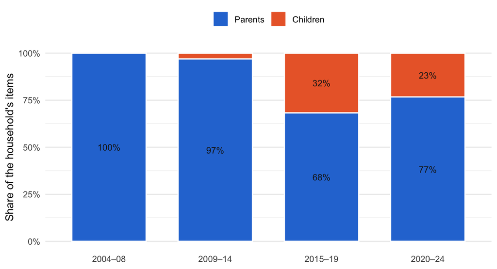

```r
shopper_cols <- c("Parents" = "#2a78d6", "Children" = "#eb6834")
member_period$shopper <- factor(member_period$shopper, levels = names(shopper_cols))

ggplot(member_period, aes(period, pct, fill = shopper)) +
  geom_col(width = 0.7, color = "white", linewidth = 0.6,
           position = position_stack(reverse = TRUE)) +
  geom_text(aes(label = ifelse(pct >= 5, sprintf("%.0f%%", pct), "")),
            position = position_stack(vjust = 0.5, reverse = TRUE),
            size = 3.2, color = "#1a1a1a") +
  scale_fill_manual(values = shopper_cols, name = NULL) +
  scale_y_continuous(labels = function(x) paste0(x, "%")) +
  labs(x = NULL, y = "Share of the household's items") +
  theme_minimal() +
  theme(legend.position = "top", panel.grid.major.x = element_blank())
```

**Takeaway:** Parents bought everything through 2008 and 97% of items in 2009–14. From 2015 on, both children had left for college. Their purchases accounted for about one third of items (2015–19) and a quarter (2020–24). The main difference in how the two generations shop is price: the parents’ typical item cost about $19, against about $15 for the children.

## 5. Purchasing ‘holidays’

**Show SQL**

```sql
-- Share of each era's orders placed in each calendar month
SELECT era, month, orders,
       100.0 * orders / SUM(orders) OVER (PARTITION BY era) AS pct
FROM (
  SELECT CASE WHEN year < 2015 THEN '2004–2014' ELSE '2015–2024' END AS era,
         month(order_date) AS month,
         COUNT(*)          AS orders
  FROM order_level
  GROUP BY 1, 2
);
```

**Show R**

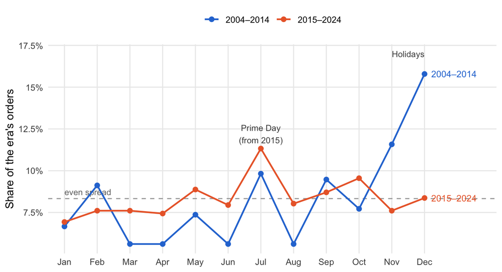

```r
era_cols <- c("2004–2014" = "#2a78d6", "2015–2024" = "#eb6834")

ggplot(month_share, aes(month, pct, color = era)) +
  geom_hline(yintercept = 100 / 12, linetype = "dashed", color = "grey65") +
  annotate("text", x = 1, y = 100 / 12, label = "even spread",
           vjust = -0.6, hjust = 0, size = 3, color = "grey45") +
  geom_line(linewidth = 0.8) +
  geom_point(size = 2) +
  geom_text(data = subset(month_share, month == 12),
            aes(label = era), hjust = -0.15, size = 3.2, show.legend = FALSE) +
  annotate("text", x = 7, y = 12.2, label = "Prime Day\n(from 2015)",
           size = 3, color = "grey30") +
  annotate("text", x = 11.5, y = 17, label = "Holidays",
           size = 3, color = "grey30") +
  scale_color_manual(values = era_cols, name = NULL) +
  scale_x_continuous(breaks = 1:12, labels = month.abb,
                     expand = expansion(add = c(0.5, 2.2))) +
  scale_y_continuous(labels = function(x) paste0(x, "%")) +
  labs(x = NULL, y = "Share of the era's orders") +
  theme_minimal() +
  theme(legend.position = "top", panel.grid.minor = element_blank())
```

**Takeaway:** The household’s busiest month moved from December to July. Before 2015, November and December held 27% of orders reflecting a holiday peak. From 2015 on, orders spread almost evenly across the year (7–10% a month) except July, the busiest month at 11%. That lines up with Prime Day, Amazon’s members-only summer sale, first held in July 2015. Part of the holiday fade is dilution: once routine top-ups dominated, seasonal shopping became a smaller share of the total.

## Appendix: Data & methods

**NoteData sources, quality audit and cleaning code**

**Data.** One household’s Amazon order history, 2004–2024 (2,715 line items, 1,505 orders). Before analysis, addresses, names, payment card digits, tracking numbers and exact timestamps were removed or replaced with pseudonyms (`Member A`–`D`, `Location 01`); for the analysis, household members are grouped as Parents (two members) and Children (two members). Product names were replaced with a broad category: books were identified by their ISBN-style product code and everything else by keyword rules; items no rule matched are labeled “Other”. The product names themselves are not published.

**Show SQL**

```sql
-- Coverage: items and orders per year
SELECT purchase_year             AS "Year",
       COUNT(*)                  AS "Items",
       COUNT(DISTINCT order_num) AS "Orders"
FROM orders_raw
GROUP BY purchase_year
ORDER BY purchase_year;
```

| Year | Items | Orders |
| --- | --- | --- |
| 2004 | 23 | 2 |
| 2005 | 38 | 5 |
| 2006 | 22 | 7 |
| 2007 | 18 | 4 |
| 2008 | 14 | 3 |
| 2009 | 30 | 18 |
| 2010 | 66 | 44 |
| 2011 | 69 | 38 |
| 2012 | 61 | 37 |
| 2013 | 101 | 61 |
| 2014 | 137 | 73 |
| 2015 | 214 | 111 |
| 2016 | 144 | 75 |
| 2017 | 213 | 104 |
| 2018 | 191 | 100 |
| 2019 | 192 | 119 |
| 2020 | 286 | 152 |
| 2021 | 181 | 141 |
| 2022 | 192 | 112 |
| 2023 | 290 | 183 |
| 2024 | 233 | 116 |

**Show SQL**

```sql
-- Missing values vs. placeholder text
SELECT 'Missing shipment subtotal'   AS "Check", COUNT(*) FILTER (WHERE order_total IS NULL) AS "Items" FROM orders_raw
UNION ALL
SELECT 'Missing ship date',                   COUNT(*) FILTER (WHERE ship_date   IS NULL) FROM orders_raw
UNION ALL
SELECT '"na" text in shipping option',        COUNT(*) FILTER (WHERE ship_type   = 'na')  FROM orders_raw
UNION ALL
SELECT '"na" text in condition',              COUNT(*) FILTER (WHERE condition   = 'na')  FROM orders_raw
UNION ALL
SELECT '"na" text in payment type',           COUNT(*) FILTER (WHERE pay_type    = 'na')  FROM orders_raw;
```

| Check | Items |
| --- | --- |
| Missing shipment subtotal | 54 |
| Missing ship date | 62 |
| “na” text in shipping option | 124 |
| “na” text in condition | 63 |
| “na” text in payment type | 103 |

**Cleaning.** These views run in a hidden setup step at the top of the page; the code is shown here for reference.

**Show SQL**

```sql
CREATE OR REPLACE VIEW orders_raw AS
SELECT * FROM read_csv_auto('data/amazon_deid.csv');
CREATE OR REPLACE VIEW orders AS
SELECT * REPLACE (
  TRY_CAST(order_total AS DOUBLE) AS order_total,  -- defensive: NULL if not numeric
  NULLIF(ship_type, 'na') AS ship_type,             -- "na" text -> real NULL
  NULLIF(condition, 'na') AS condition,
  NULLIF(pay_type,  'na') AS pay_type
),
CASE WHEN household_member IN ('Member A', 'Member D') THEN 'Parents'
     WHEN household_member IN ('Member B', 'Member C') THEN 'Children'
END AS shopper                              -- household roles
FROM orders_raw
WHERE status = 'Closed';   -- exclude cancelled items
```